# Swing Trader · Control Centre

The cheat sheet, with the panels made operable. Three columns: choose the inputs, fit and tune the model, read the result.

PAPER ONLY **$81,713** *-$18,287* · open 0 *$0* · closed 112 *-$10,030* · cash $81,713 seamusrobertmurphy/swing-trader · nothing here can place an order

A1Data➞ A2Indicators➞ B1Variables➞ B2Training➞ C1Scoreboard➞ C2Ledger

### Quick start Glossary

Choose Binance crypto or Alpaca US stocks, pick a preset to fill every setting, then press Run Model.

### Run your model

Sends your saved settings, trains your model on fresh prices and issues a paper trade per coin or stock, in about five minutes. Nothing is bought or sold.

See results and paper trades

## A1Datamarket, basket, filter, ranking, label

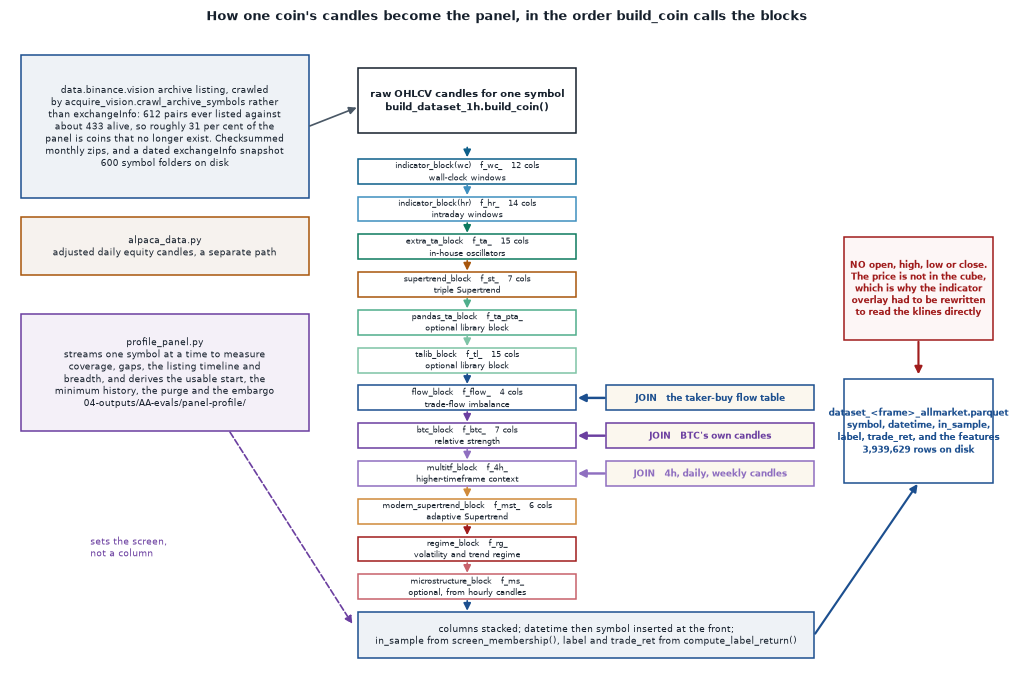

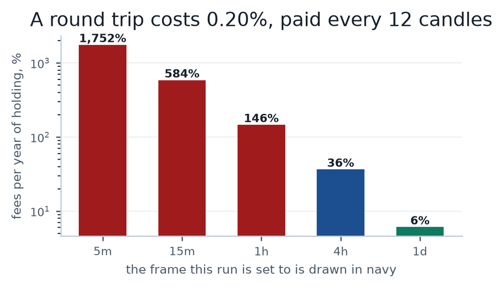

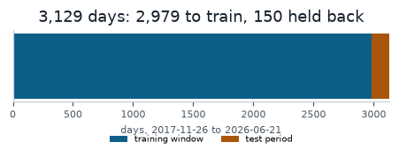

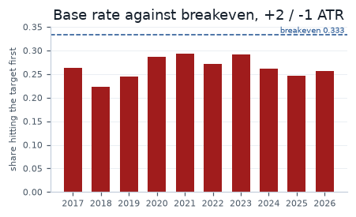

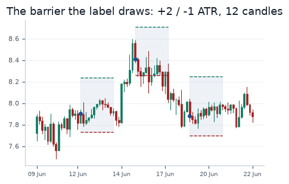

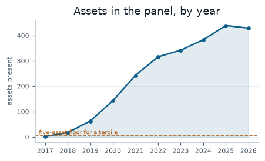

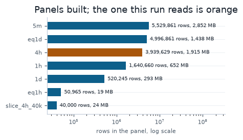

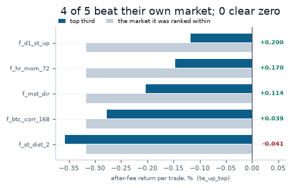

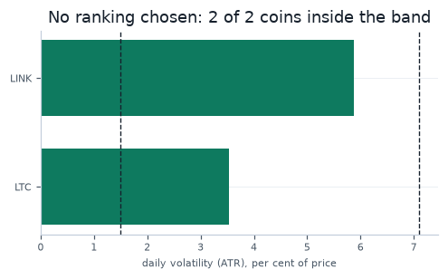

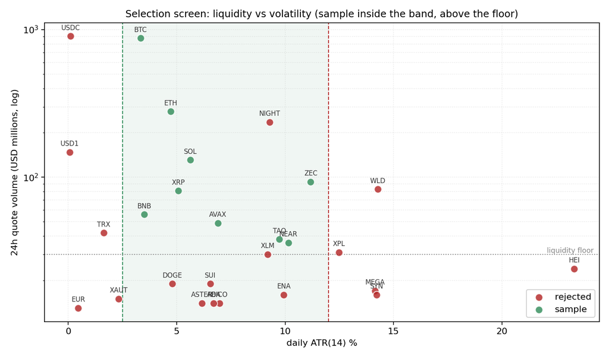

3/10

Training window against test period

[figure not shown]

[figure not shown]

[figure not shown]

[figure not shown]

[figure not shown]

[figure not shown]

[figure not shown]

[figure not shown]

[figure not shown]

[figure not shown]

2/10

What a round trip costs, by timeframe

Market, timeframe, symbols, screen.

## A2Indicatorsfeatures, macd, averages, fibonacci, confluence

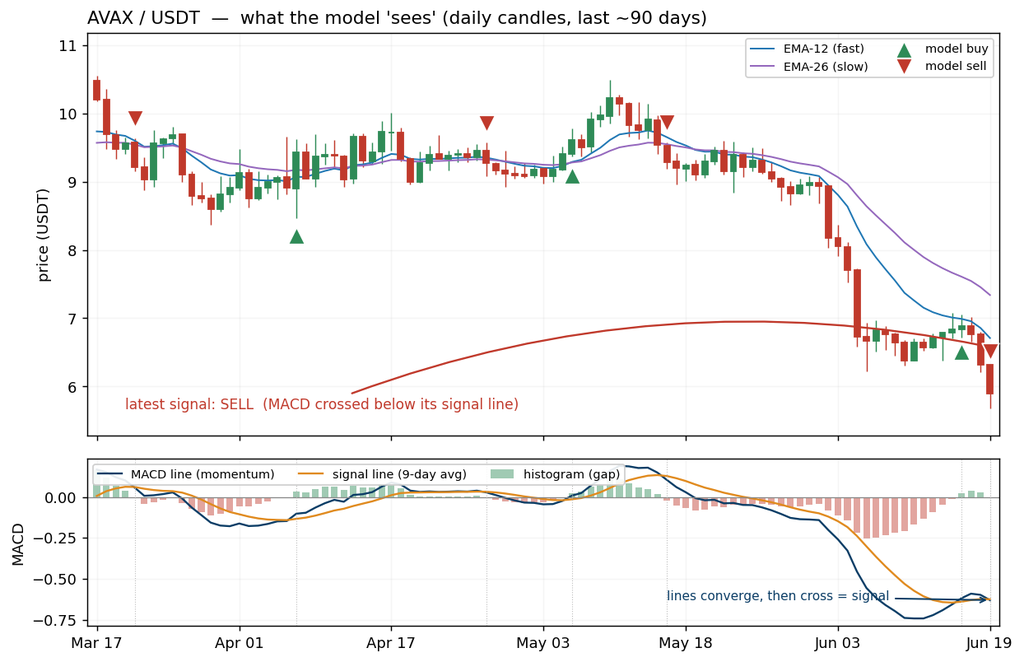

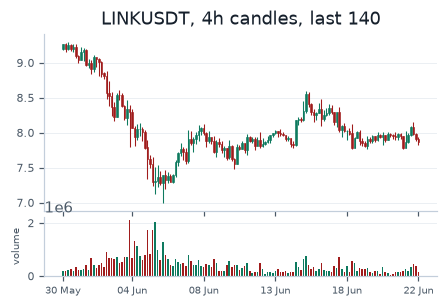

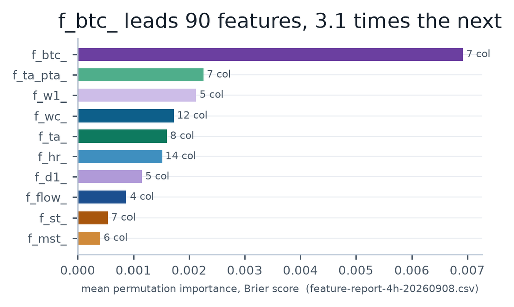

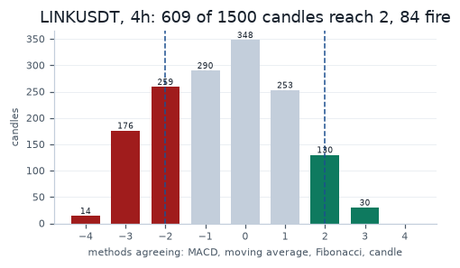

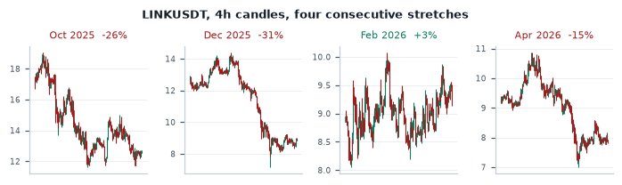

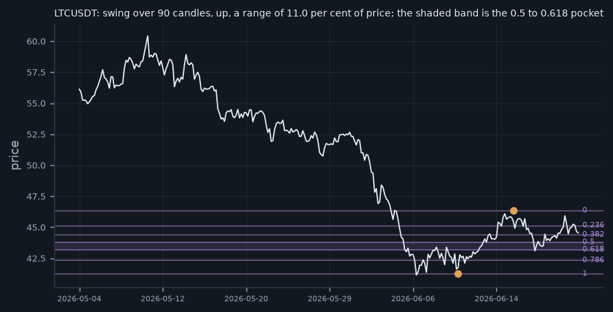

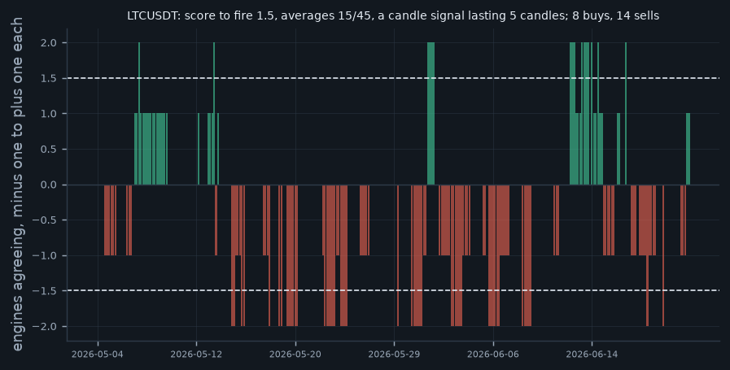

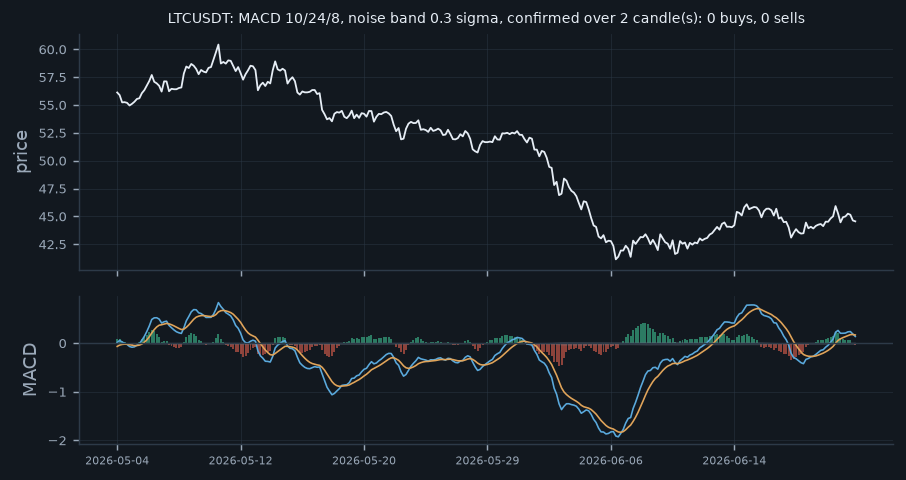

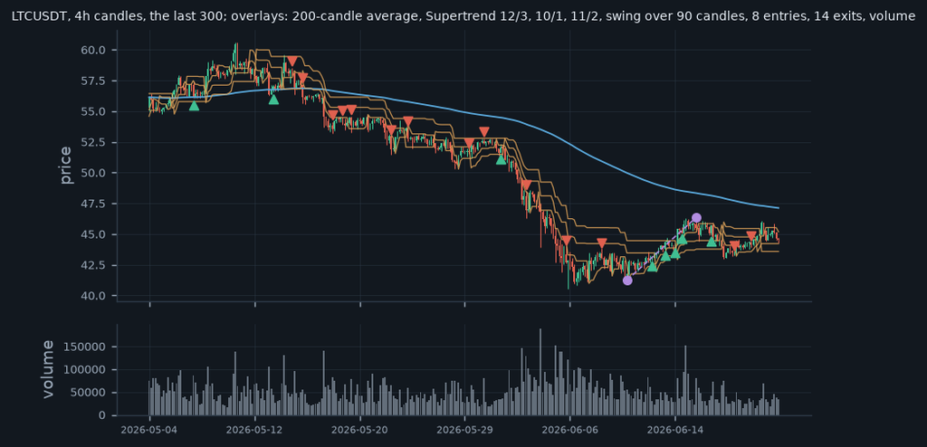

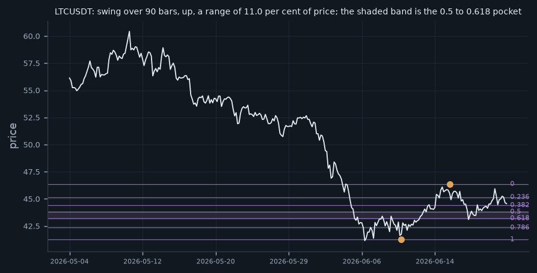

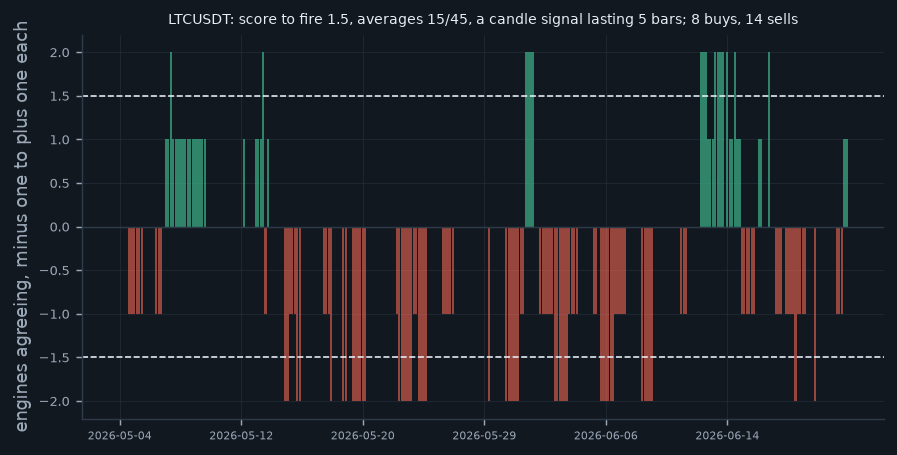

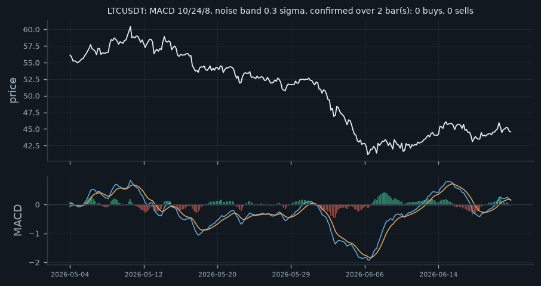

[1 more figures not shown]

4/22